# STAT 432 Homework 04

Kevin Wong - kjwong2

Due:** Friday, February 23, 11:59 PM

Please see the [homework policy document](https://daviddalpiaz.github.io/stat432sp18/homework_policy.html) for detailed instructions and some grading notes. Failure to follow instructions will result in point reductions.

> “Better three hours too soon than a minute too late.”

> — **William Shakespeare**

For this homework, you may only use the following packages:

```r
# general
library(caret)
library(tidyverse)
library(knitr)
library(kableExtra)
library(e1071)

# specific
library(ISLR)
library(pROC)
```

If you feel additional general packages would be useful for future homework, please pass these along to the instructor.

# Exercise 1 (Logistic Regression for Fuel Efficiency)

**[6 points]** For this exercise we will use the `Auto` data from the `ISLR` package.

```r
data(Auto)
```

As we have seen before, we drop the `name` variable. We also coerce `origin` and `cylinders` to be factors as they are categorical variables.

We also re-create a new response variable `mpg.` Instead of the actual fuel efficiency, we simply label cars that obtain fewer than 30 miles per gallon as ‘low’ fuel efficiency. Those above 30 have ‘high’ fuel efficiency.

```r
Auto = subset(Auto, select = -c(name))
Auto$origin = factor(Auto$origin)
Auto$cylinders = factor(Auto$cylinders)
Auto$mpg = factor(ifelse(Auto$mpg < 30, "low", "high"))
```

After these modifications, we test-train split the data.

```r
set.seed(1)
auto_trn_idx  = sample(nrow(Auto), size = trunc(0.75 * nrow(Auto)))
auto_trn_data = Auto[auto_trn_idx, ]
auto_tst_data = Auto[-auto_trn_idx, ]
```

The goal of our modeling in this exercise is to predict whether or not a vehicle is fuel efficient.

Fit five different logistic regressions.

- **Intercept**: $\log \left( \frac{p(x)}{1 - p(x)} \right) = \beta_0$
- **Simple**: $\log \left( \frac{p(x)}{1 - p(x)} \right) = \beta_0 + \beta_1 \texttt{horsepower}$
- **Multiple**:$\log \left( \frac{p(x)}{1 - p(x)} \right) = \beta_0 + \beta_1 \texttt{horsepower} + \beta_2 \texttt{euro} + \beta_3 \texttt{japan}$
- **Additive**: An *additive* model using all available predictors
- **Interaction**: An *interaction* model that includes all first order terms and all possible two-way interactions

Here we’ll define $p(x) = P(Y = \texttt{low} \mid X = x)$. The variables `euro` and `japan` are dummy variables based on the `origin` variables. **Do not make these variables by modifying the data.**

Using each of these models to estimate $p(x)$, that is estimate the probability of a `low` fuel efficiency given the characteristics of a vehicle, we can create a classifier.

$$\hat{C}(x) =
\begin{cases}
\texttt{low} & \hat{p}(x) > 0.5 \\
\texttt{high} & \hat{p}(x) \leq 0.5
\end{cases}$$

For each classifier, obtain train and test classification error rates. Summarize your results in a well-formatted markdown table.

**Solution:**

```r
glm_mod_intcept = glm(mpg ~ 1, data = auto_trn_data, family = "binomial")
glm_mod_simp = glm(mpg ~ horsepower, data = auto_trn_data, family = "binomial")
glm_mod_mult = glm(mpg ~ horsepower + origin - cylinders, data = auto_trn_data, family = "binomial")
glm_mod_add = glm(mpg ~ ., data = auto_trn_data, family = "binomial")
glm_mod_intact = glm(mpg ~ . ^ 2, data = auto_trn_data, family = "binomial")
```

```r
calc_class_err = function(actual, predicted) {
  mean(actual != predicted)
}

get_logistic_error = function(mod, data, res = "y", pos = 1, neg = 0, cut = 0.5) {
  probs = predict(mod, newdata = data, type = "response")
  preds = ifelse(probs > cut, pos, neg)
  calc_class_err(actual = data[, res], predicted = preds)
}
```

```r
mod_list_ex1 = list(glm_mod_intcept, glm_mod_simp, glm_mod_mult, glm_mod_add, glm_mod_intact)

train_errors_ex1 = sapply(mod_list_ex1, get_logistic_error, data = auto_trn_data, res = "mpg", pos = "low", neg = "high", cut = 0.5)
test_errors_ex1 = sapply(mod_list_ex1, get_logistic_error, data = auto_tst_data, res = "mpg", pos = "low", neg = "high", cut = 0.5)
```

| Model Name | Training Class Error Rate | Testing Class Error Rate |
| --- | --- | --- |
| glm_mod_intcept | 0.224 | 0.245 |
| glm_mod_simp | 0.143 | 0.122 |
| glm_mod_mult | 0.136 | 0.102 |
| glm_mod_add | 0.078 | 0.061 |
| glm_mod_intact | 0.051 | 0.122 |

# Exercise 2 (Detecting Cancer with Logistic Regression)

**[6 points]** For this exercise we will use data found in `wisc-trn.csv` and `wisc-tst.csv` which contain train and test data respectively. `wisc.csv` is provided but not used. This is a modification of the Breast Cancer Wisconsin (Diagnostic) dataset from the UCI Machine Learning Repository. Only the first 10 feature variables have been provided. (And these are all you should use.)

- UCI Page
- [Data Detail](https://archive.ics.uci.edu/ml/machine-learning-databases/breast-cancer-wisconsin/wdbc.names)

You should consider coercing the response to be a factor variable.

Consider an additive logistic regression that considers *only two predictors*, `radius` and `symmetry`. Use this model to estimate

$$p(x) = P(Y = \texttt{M} \mid X = x).$$

Report test sensitivity, test specificity, and test accuracy for three classifiers, each using a different cutoff for predicted probability:

$$\hat{C}(x) =
\begin{cases}
M & \hat{p}(x) > c \\
B & \hat{p}(x) \leq c
\end{cases}$$

- $c = 0.1$
- $c = 0.5$
- $c = 0.9$

We will consider `M` (malignant) to be the “positive” class when calculating sensitivity and specificity. Summarize these results using a single well-formatted table.

**Solution:**

```r
wisc_trn_data = read.csv("wisc-trn.csv")
wisc_tst_data = read.csv("wisc-tst.csv")
model_ex2 = glm(class ~ radius + symmetry, data = wisc_trn_data, family = "binomial")
```

```r
get_logistic_pred = function(mod, data, res = "y", pos = 1, neg = 0, cut = 0.5) {
  probs = predict(mod, newdata = data, type = "response")
  ifelse(probs > cut, pos, neg)
}
```

```r
test_tab_10 = table(predicted = test_pred_10, actual = wisc_tst_data$class)
test_tab_50 = table(predicted = test_pred_50, actual = wisc_tst_data$class)
test_tab_90 = table(predicted = test_pred_90, actual = wisc_tst_data$class)

test_con_mat_10 = confusionMatrix(test_tab_10, positive = "M")
test_con_mat_50 = confusionMatrix(test_tab_50, positive = "M")
test_con_mat_90 = confusionMatrix(test_tab_90, positive = "M")
```

```
##          Accuracy Sensitivity Specificity
## c = 0.10     0.86       0.950   0.8000000
## c = 0.50     0.91       0.825   0.9666667
## c = 0.90     0.82       0.575   0.9833333
```

# Exercise 3 (More Sensitivity and Specificity)

**[6 points]** Continuing the setup (data and model) from Exercise 2, we now create two plots which will help us understand the tradeoff between sensitivity and specificity.

- **Plot 1** A plot that shows (test) accuracy, sensitivity, and specificity as a function of the cutoff $c$ used to create a classifier based on the logistic regression model.
  - Use the test data.
  - Consider values of c from 0.01 to 0.99. (See `R` code below.)
  - Accuracy, sensitivity, and specificity will each be a “line” on the plot.
  - Give each line a different color and line type.
  - Give the plot a title, axis labels, and legend.
- **Plot 2** An ROC Curve
  - Use the test data.
  - Display the AUC value on the plot.

Display these two plots side-by-side.

*Hint:* Consider creating some functions specific to this exercise for obtaining accuracy, sensitivity, and specificity. (If you didn’t already do so in Exercise 2.)

**Solution:**

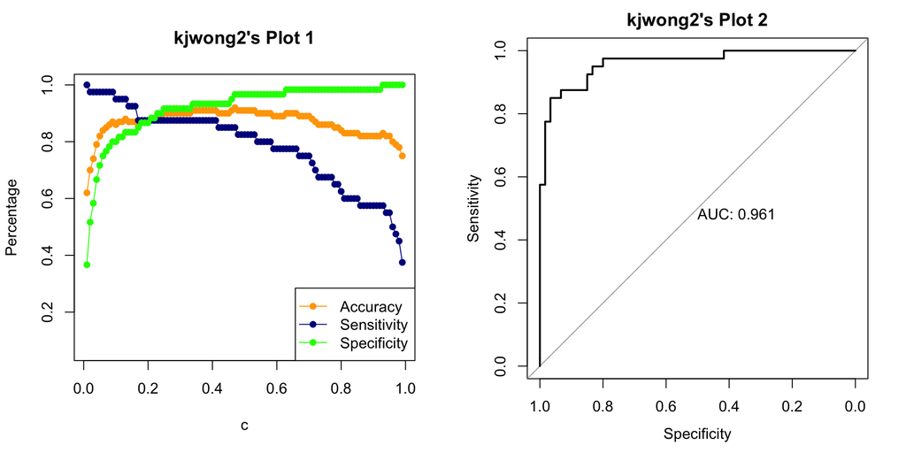

```r
par(mfrow = c(1, 2))
plot(c, preds[1,], col = "orange", pch = 16, ylab = "Percentage", main = "kjwong2's Plot 1", ylim = (c(min(preds[1,], preds[2,], preds[3,] - 0.3), 1)))
lines(c, preds[1,], col = "orange")
points(c, preds[2,], col = "darkblue", pch = 16)
lines(c, preds[2,], col = "darkblue")
points(c, preds[3,], col = "green", pch = 16)
lines(c, preds[3,], col = "green")
legend("bottomright", c("Accuracy", "Sensitivity", "Specificity"), lwd = 1,
       col = c("orange", "darkblue", "green"), pch = c(16, 16, 16))

test_prob = predict(model_ex2, newdata = wisc_tst_data, type = "response")
test_roc = roc(wisc_tst_data$class ~ test_prob, plot = TRUE, main = "kjwong2's Plot 2", print.auc = TRUE)
```

# Exercise 4 (Logistic Regression Decision Boundary)

**[6 points]** Continue with the cancer data from previous exercises. Again, consider an additive logistic regression that considers *only two predictors*, `radius` and `symmetry`. Plot the test data with `radius` as the $x$ axis, and `symmetry` as the $y$ axis, with the points colored according to their tumor status. Add a line which represents the decision boundary for a classifier using 0.5 as a cutoff for predicted probability.

**Solution**

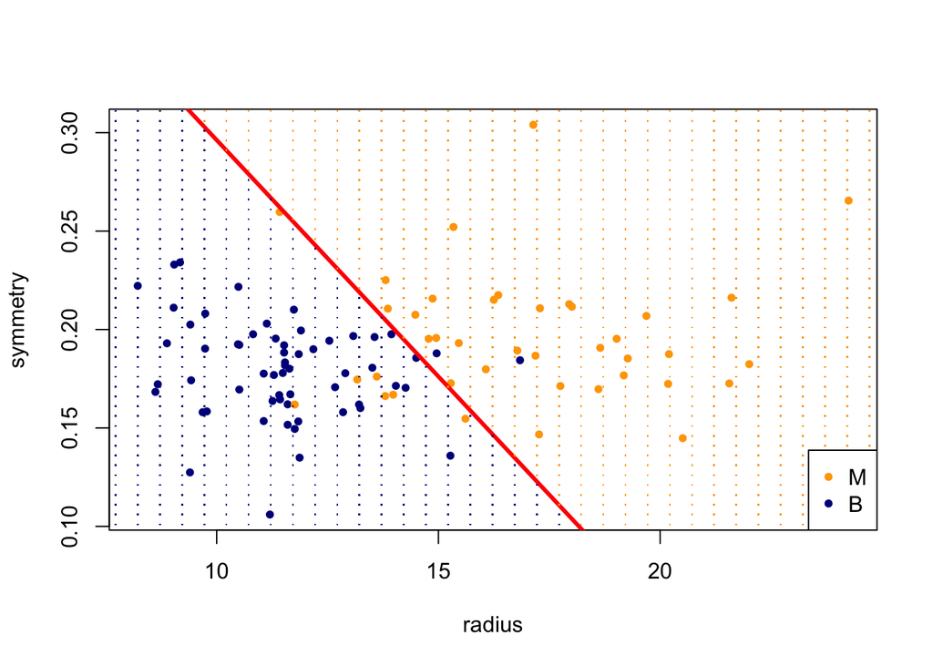

# Exercise 5 (Concept Checks)

**[1 point each]** Answer the following questions based on your results from the three exercises.

**(a)** What is $\hat{\beta}_2$ for the **multiple** model in Exercise 1? - The $\hat{\beta}_2$ value for the *Multiple** model in Exercise 1 is 0.1001925.

**(c)** Based on your results in Exercise 1, which of these models do you think may be underfitting? - The *Intercept*, *Simple*, and *Multiple* models are *underfitting* because the *Additive* model is a more complex model with a lower Testing Class Error Rate.

**(d)** Based on your results in Exercise 1, which of these models do you think may be overfitting?? - The *Interaction* model is *overfitting* because the *Additive* model is a less complex model with a lower Testing Class Error Rate.

**(f)** State the metric you used to make your decision in part **(d)**, and a reason for using that metric. - I used Accuracy for my decision because Accuracy accounts for True Positives and True Negatives. Specificity is good as well because it accounts for True Negatives